# R you ready to ggplot2?

Understanding the Grammar of Graphics  
October 10, 2014

Tony Fujs

# Objective:

# Get familiar with the logic of the Grammar of Graphics framework.

# Let's start with something everyone is familiar with…

## PRACTICE TIME!!

## Draw a scatter plot of this dataset

## PRACTICE TIME!!

## Think about the steps you took to draw your plot

# You probably did something along these lines…

### Scatter plots: STEP 1

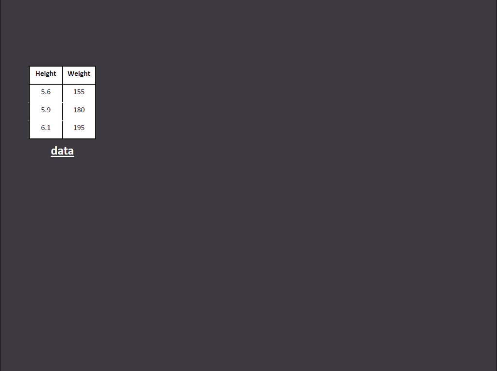

First, you looked at your **data**.

### Scatter plots: STEP 2

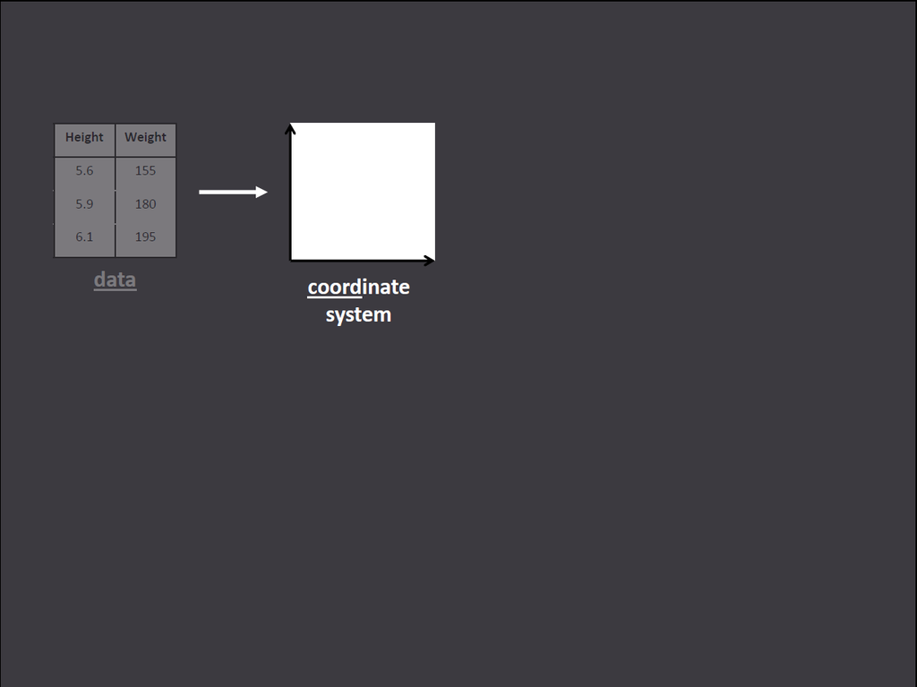

Then, you probably drew the axes of your plot. In the grammer of graphics framework. This is called a **coordinate system**

### Scatter plots: STEP 3

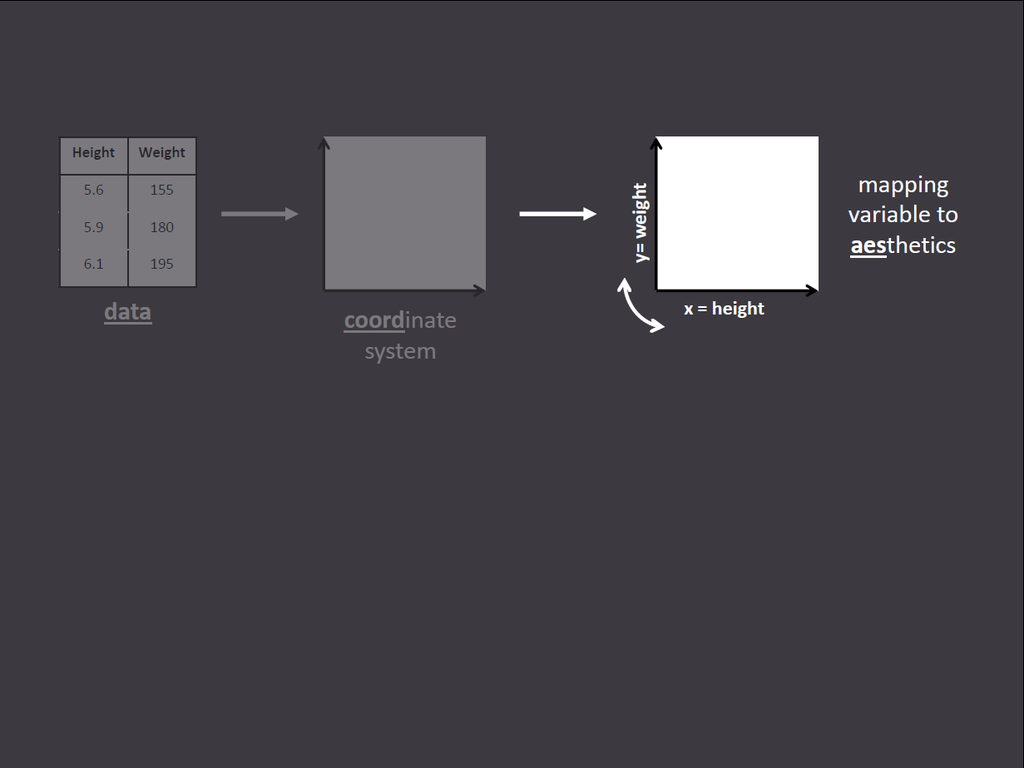

Next, you decided whether “height” should be represented on the x or y axis. In the world of the grammar of graphics, this is known as mapping variables to **aesthetics**. Aesthetics can be positions (x and y axis), but also things like size, color, shape, etc.

### Scatter plots: STEP 4

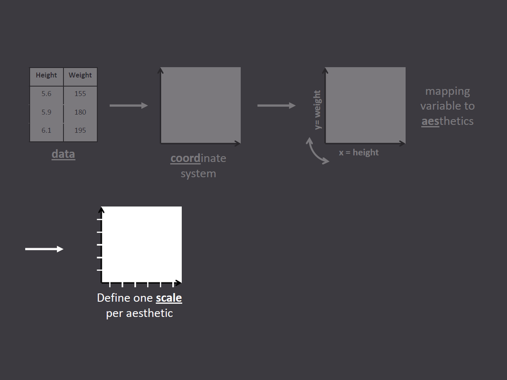

After that, you had to define a **scale** to map your variables on your sheet of paper, and adequately draw tickmarks on your x and y axes.

### Scatter plots: STEP 5

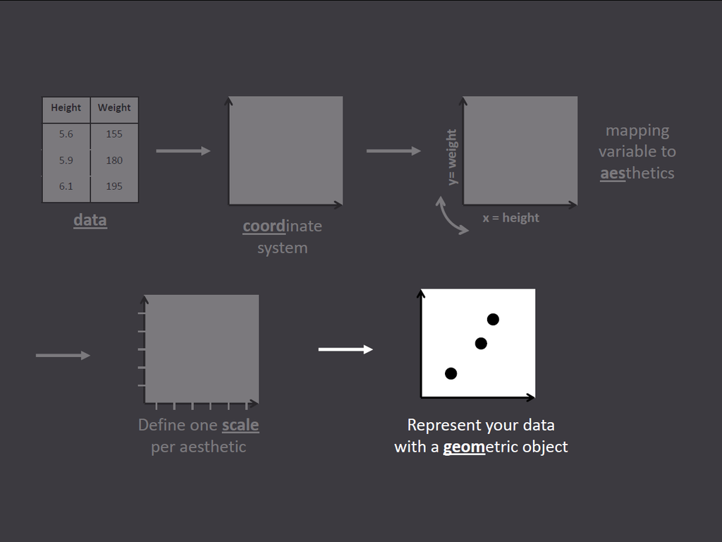

Finally, you represented each row in the table, by a point on your plot. In the grammar of graphics world, data are represented with **geometric objects**. Geometric objects can be point, bar, line, etc.

### Congratulations!!

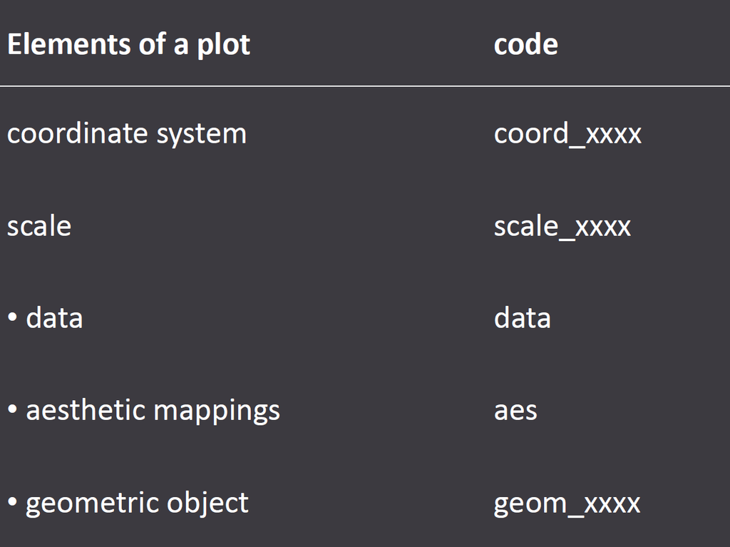

You just **identified 5 of 7 key elements of the grammar of graphics**. Almost any -2d- plot can be represented by specifying adequately each one of these 7 elements.

# Let's take a closer look at each element separately

### Slide structure

- Data set goes here:

```
  year state stores
1 2005    FL    174
2 2005    MI     76
3 2005    NJ     41
4 2005    NV     22
5 2005    VT      4
```

- Code goes here:

  ```r
  simplified R code
  ```

- Plot goes here:

### DATA

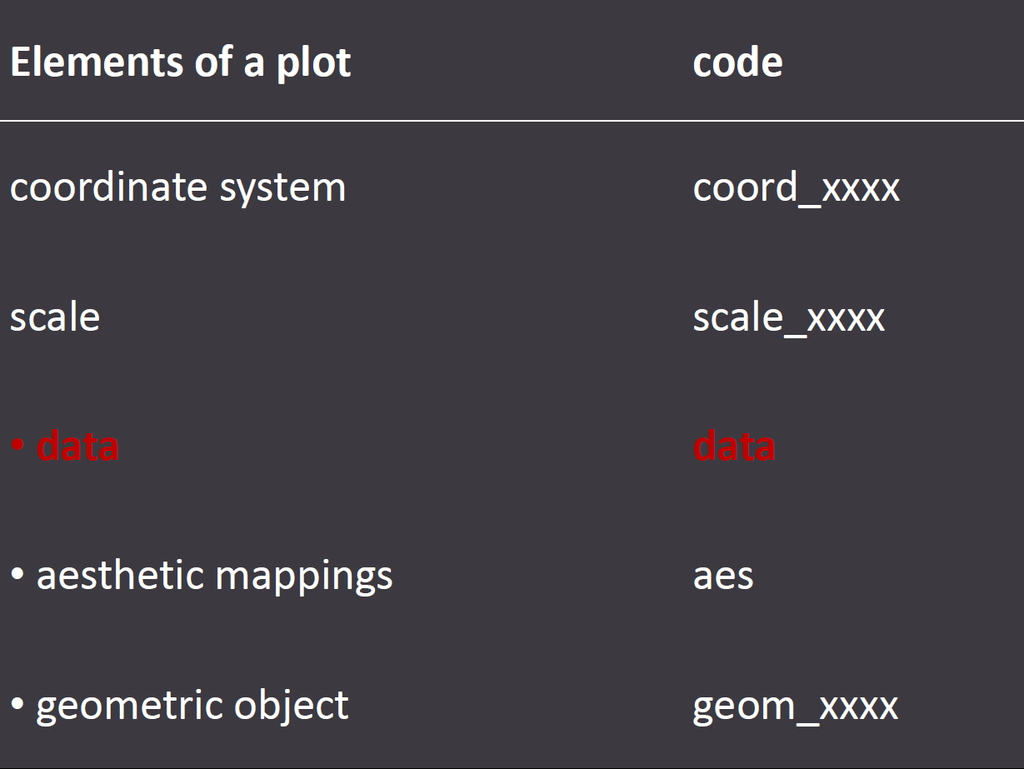

### DATA

```
  year state stores
1 2005    FL    174
2 2005    MI     76
3 2005    NJ     41
4 2005    NV     22
5 2005    VT      4
```

```r
data = mini_walmart
```

Specifying your data set is really straightforward. If you want to visualize a data set named, say, “mini_walmart”, you only need to write: **data = mini_walmart**

### AESTHETIC MAPPING

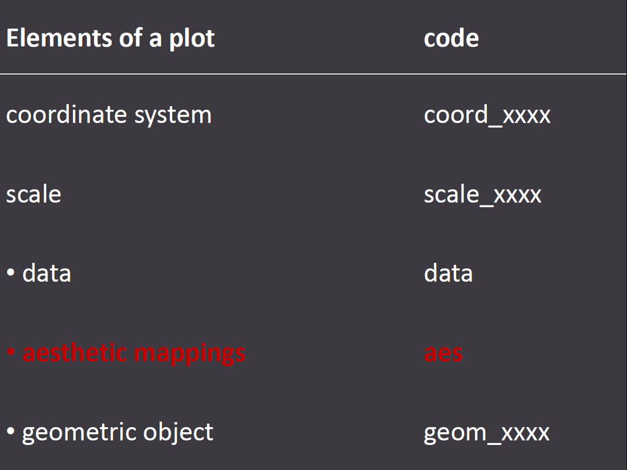